# Análise de Frequência de Precipitações Máximas Diárias

Lucas

2026-03-05

## 1. Introdução e Preparação dos Dados

Nesta análise, exploramos uma série temporal de precipitações máximas diárias anuais (1961-2025) da cidade de Teófilo Otoni utilizando a Teoria de Valores Extremos (TVE). Os dados são oriúndos do Banco de Dados Metereológicos -BDMEP do Instituto Nacional de Metereologia - INMET. O objetivo principal é ajustar um modelo estatístico capaz de estimar tempos de retorno para eventos climáticos severos que ocorrem na região de Teófilo Otoni, que comumente sofre com enchentes e alagamentos causados por essas condições.

```r
# Criando o vetor de precipitações máximas
PRECIP <- c(
  63.9, 70.2, 75.8, 108.1, 86.4, 68.9, 46.2, 54.4, 62.5, 82.9, 66.8, 61.4,
  62.2, 73.1, 150.3, 69.0, 59.8, 54.1, 83.0, 58.6, 102.7, 59.9, 92.8, 70.9,
  79.2, 68.1, 95.4, 47.6, 62.0, 155.9, 66.0, 89.4, 72.6, 68.6, 60.9, 78.0,
  68.7, 57.4, 56.0, 89.6, 80.4, 246.4, 64.0, 120.7, 91.0, 102.1, 49.2, 96.5,
  104.4, 72.0, 69.8, 145.0, 82.6, 82.2, 75.8, 137.6, 70.2, 58.0, 64.2, 93.6,
  75.6, 96.4, 44.8, 91.4, 67.2
)

# Resumo estatístico
summary(PRECIP)
```

```
##    Min. 1st Qu.  Median    Mean 3rd Qu.    Max.
##   44.80   62.50   72.00   81.24   91.00  246.40
```

```r
# Criando a série temporal
year <- seq(1961, 2025, 1)
precip_ts <- ts(PRECIP, start = min(year), frequency = 1)
```

### Visualização da Série Histórica

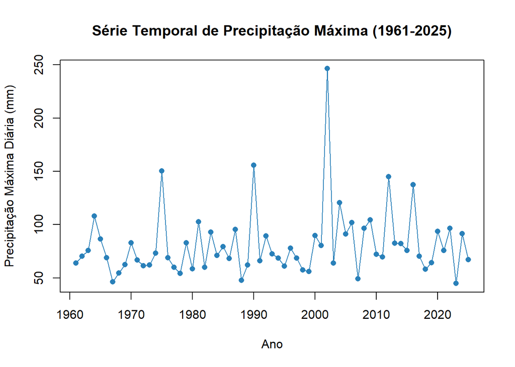

```r
plot(precip_ts, type = "o", col = "#2980b9", pch = 16,
     ylab = "Precipitação Máxima Diária (mm)", xlab = "Ano",
     main = "Série Temporal de Precipitação Máxima (1961-2025)")
```

## 2. Análise Exploratória e Testes de Premissas

Antes da modelagem, verificamos a estacionariedade, a presença de tendências monotônicas e a autocorrelação da série, premissas fundamentais para a aplicação do modelo de extremos de forma estacionária.

**Hipóteses do Teste de Ljung-Box (Autocorrelação):** * **$H_0$:** Os dados são distribuídos de forma independente (não há autocorrelação serial até o *lag* testado). * **$H_1$:** Os dados não são independentes (existe autocorrelação serial).

**Hipóteses dos Testes de Cox-Stuart e Mann-Kendall (Tendência):** * **$H_0$:** Não existe tendência (monotônica) na série temporal. * **$H_1$:** Existe uma tendência (crescente ou decrescente) na série.

**Hipóteses do Teste Dickey-Fuller Aumentado - ADF (Estacionariedade):** * **$H_0$:** A série temporal possui uma raiz unitária (é não-estacionária). * **$H_1$:** A série temporal não possui raiz unitária (é estacionária).

```r
# Pacotes necessários
library(randtests)
library(Kendall)
library(tseries)

# 1. Teste de Autocorrelação (Ljung-Box no lag 10)
Box.test(precip_ts, type = "Ljung-Box", lag = 10)
```

```
##
##  Box-Ljung test
##
## data:  precip_ts
## X-squared = 11.615, df = 10, p-value = 0.3117
```

```r
# 2. Testes de Tendência
cox.stuart.test(precip_ts)
```

```
##
##  Cox Stuart test
##
## data:  precip_ts
## statistic = 18, n = 32, p-value = 0.5966
## alternative hypothesis: non randomness
```

```r
MannKendall(precip_ts)
```

```
## tau = 0.124, 2-sided pvalue =0.14566
```

```r
# 3. Teste de Estacionariedade (Dickey-Fuller Aumentado)
adf.test(precip_ts)
```

```
##
##  Augmented Dickey-Fuller Test
##
## data:  precip_ts
## Dickey-Fuller = -3.6996, Lag order = 3, p-value = 0.03186
## alternative hypothesis: stationary
```

### Avaliação de Normalidade

Na climatologia de extremos, espera-se que a distribuição dos máximos anuais seja assimétrica e com cauda pesada. Portanto, o ideal é **rejeitar** a normalidade.

**Hipóteses do Teste Kolmogorov-Smirnov (Série Bruta):** * **$H_0$:** Os dados seguem uma distribuição Normal. * **$H_1$:** Os dados não seguem uma distribuição Normal.

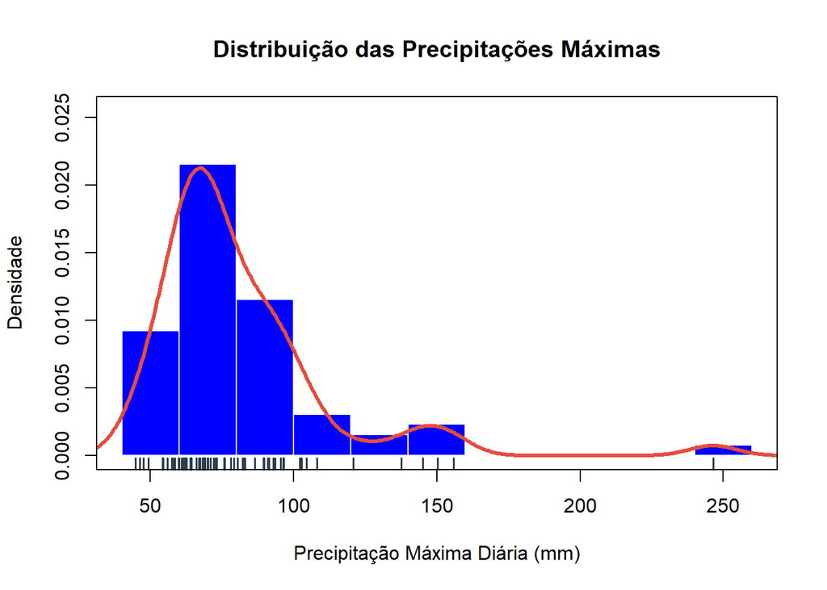

```r
densidade_precip <- density(PRECIP)

hist(PRECIP, breaks = 12, prob = TRUE,
     col = "blue", border = "white",
     main = "Distribuição das Precipitações Máximas",
     xlab = "Precipitação Máxima Diária (mm)",
     ylab = "Densidade",
     ylim = c(0, max(densidade_precip$y) * 1.2))

lines(densidade_precip, col = "#e74c3c", lwd = 3)

rug(PRECIP, col = "#2c3e50", lwd = 1.5)
box()
```

```r
# Teste de Normalidade Clássico
ks.test(precip_ts, "pnorm", mean = mean(precip_ts), sd = sd(precip_ts))
```

```
##
##  Asymptotic one-sample Kolmogorov-Smirnov test
##
## data:  precip_ts
## D = 0.17012, p-value = 0.04646
## alternative hypothesis: two-sided
```

## 3. Ajuste do Modelo GEV

Utilizamos a Distribuição Generalizada de Valores Extremos (GEV) para modelar a série de máximos anuais. A avaliação inicial do parâmetro de forma ($\xi$) define a família da distribuição.

```r
library(ismev)
library(extRemes)

# Ajuste inicial e diagnóstico visual
B <- gev.fit(precip_ts)
```

```
## $conv
## [1] 0
##
## $nllh
## [1] 292.6398
##
## $mle
## [1] 67.3141928 16.5379833  0.2074347
##
## $se
## [1] 2.29791523 1.81893610 0.09357396
```

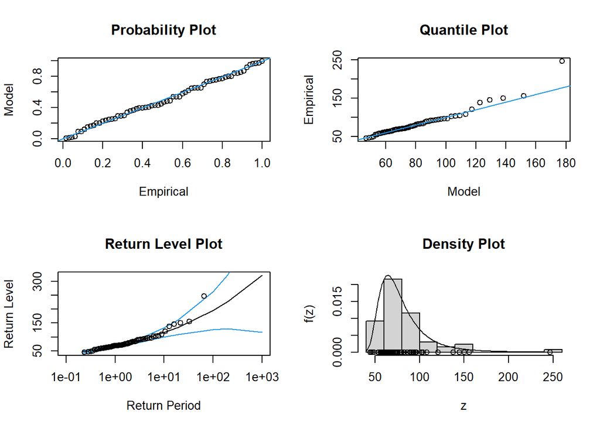

```r
gev.diag(B)
```

Avaliamos também a incerteza dos parâmetros utilizando a Verossimilhança Perfilada para diferentes tempos de retorno, gerando intervalos de confiança mais robustos para distribuições de cauda pesada.

```r
# Ajuste com extRemes
fit1 <- fevd(PRECIP, units = "mm")

par(mfrow=c(2,2))
b1 <- ci(fit1, method = "proflik", xrange = c(100, 140), verbose = TRUE, return.period = c(10))
b2 <- ci(fit1, method = "proflik", xrange = c(115, 190), verbose = TRUE, return.period = c(25))
b3 <- ci(fit1, method = "proflik", xrange = c(125, 240), verbose = TRUE, return.period = c(50))
b4 <- ci(fit1, method = "proflik", xrange = c(140, 310), verbose = TRUE, return.period = c(100))
```

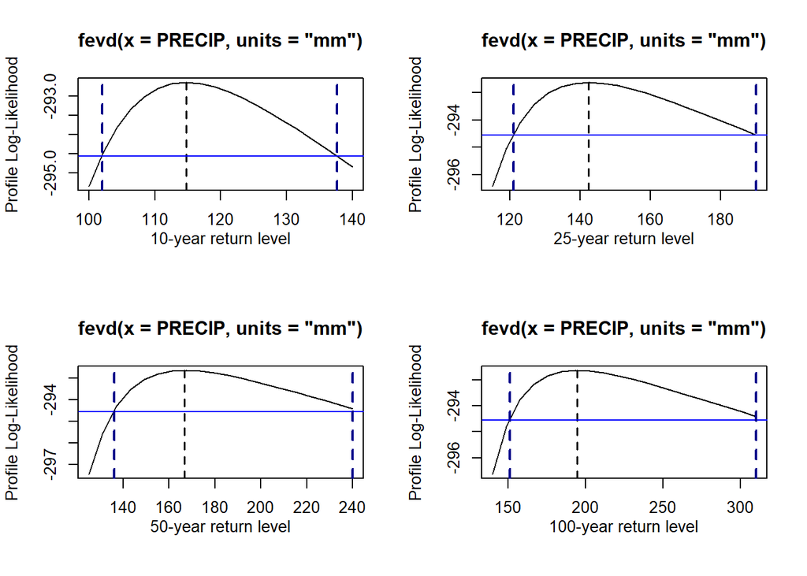

```r
par(mfrow=c(1,1))
```

## 4. Validação e Teste de Adequação (Goodness-of-Fit)

Para atestar a validade do modelo, aplicamos testes formais para verificar se a distribuição teórica estimada capta bem o comportamento dos dados observados. Neste caso, o cenário ideal é **não rejeitar** a hipótese nula ($p-valor > 0.05$).

**Hipóteses dos Testes KS e AD contra a GEV:** * **$H_0$:** A amostra observada provém da distribuição GEV ajustada. * **$H_1$:** A amostra observada não provém da distribuição GEV ajustada.

```r
library(goftest)

# Extraindo os parâmetros do modelo GEV
loc_est   <- fit1$results$par["location"]
scale_est <- fit1$results$par["scale"]
shape_est <- fit1$results$par["shape"]

# Testes de Aderência
teste_ks <- ks.test(precip_ts, "pevd", loc = loc_est, scale = scale_est, shape = shape_est)
teste_ad <- ad.test(precip_ts, "pevd", loc = loc_est, scale = scale_est, shape = shape_est)

print(teste_ks)
```

```
##
##  Asymptotic one-sample Kolmogorov-Smirnov test
##
## data:  precip_ts
## D = 0.048636, p-value = 0.9979
## alternative hypothesis: two-sided
```

```r
print(teste_ad)
```

```
##
##  Anderson-Darling test of goodness-of-fit
##  Null hypothesis: distribution 'pevd'
##  with parameters loc = 67.3193617246414, scale = 16.5463977274775, shape
##  = 0.207373645504919
##  Parameters assumed to be fixed
##
## data:  precip_ts
## An = 0.24189, p-value = 0.9745
```

> **Nota de Discussão:** O p-valor elevado no teste de Anderson-Darling indica falha em rejeitar $H_0$, atestando uma excelente adequação da GEV aos dados extremos observados.

## 5. Níveis de Retorno Estimados

Finalmente, extraímos as previsões probabilísticas para eventos extremos futuros, considerando tempos de retorno convencionais para obras de infraestrutura.

```r
# Ajustamos o modelo avisando o pacote da estrutura de dados
df_precip <- data.frame(Chuva = precip_ts)
fit_gev <- fevd(Chuva, data = df_precip, type = "GEV")

# Cálculo dos Níveis de Retorno com Intervalos de Confiança
niveis_retorno_m0 <- return.level(fit_gev,
                                  return.period = c(10, 50, 100),
                                  do.ci = TRUE)

print(niveis_retorno_m0)
```

```
## fevd(x = Chuva, data = df_precip, type = "GEV")
##
## [1] "Normal Approx."
##
##                       95% lower CI Estimate 95% upper CI
## 10-year return level      98.59258 114.7682     130.9439
## 50-year return level     120.76853 166.7395     212.7105
## 100-year return level    126.70029 194.6600     262.6198
```

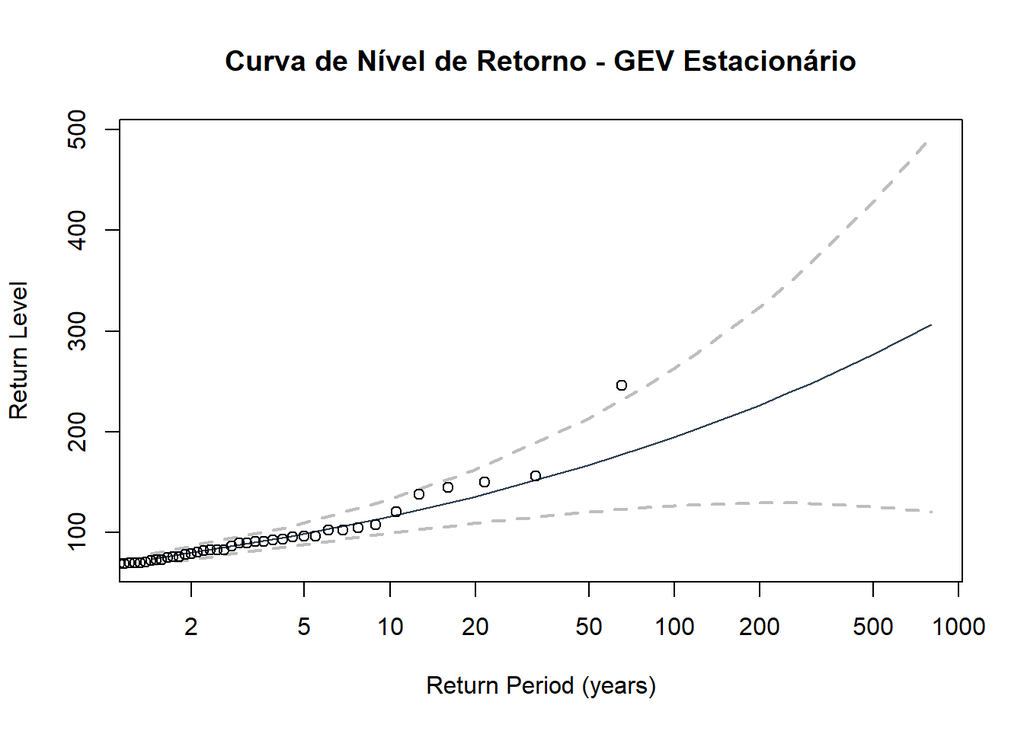

```r
# Gráfico da Curva de Retorno
plot(fit_gev, type = "rl",
     main = "Curva de Nível de Retorno - GEV Estacionário",
     pch = 19, col = "#2c3e50")
```